# Dots + interval stats and geoms

## Rain cloud plots

Sometimes you may want to include multiple different types of slabs in the same plot in order to take advantage of the features each slab type provides. For example, people often combine densities with dotplots to show the underlying datapoints that go into a density estimate, creating so-called *rain cloud* plots.

To use multiple slab geometries together, you can use the `side` parameter to change which side of the interval a slab is drawn on and set the `scale` parameter to something around `0.5` (by default it is `0.9`) so that the two slabs do not overlap. We’ll also scale the halfeye slab thickness by `n` (the number of observations in each group) so that the area of each slab represents sample size (and looks similar to the total area of its corresponding dotplot).

We’ll use a subsample of of the data to show how it might look on a reasonably-sized dataset.

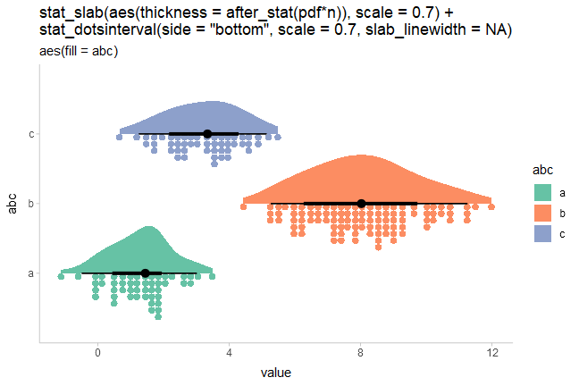

```r
set.seed(12345) # for reproducibility

data.frame(
  abc = c("a", "b", "b", "c"),
  value = rnorm(200, c(1, 8, 8, 3), c(1, 1.5, 1.5, 1))
) %>%
  ggplot(aes(y = abc, x = value, fill = abc)) +
  stat_slab(aes(thickness = after_stat(pdf*n)), scale = 0.7) +
  stat_dotsinterval(side = "bottom", scale = 0.7, slab_linewidth = NA) +
  scale_fill_brewer(palette = "Set2") +
  ggtitle(paste0(
      'stat_slab(aes(thickness = after_stat(pdf*n)), scale = 0.7) +\n',
      'stat_dotsinterval(side = "bottom", scale = 0.7, slab_linewidth = NA)'
    ),
    'aes(fill = abc)'
  )
```

## Logit dotplots

To demonstrate another useful plot type, the *logit dotplot* (courtesy [Ladislas Nalborczyk](https://lnalborczyk.github.io/post/glm/)), we’ll fit a logistic regression to some data on the sex and body mass of Gentoo penguins.

First, we’ll demo varying the `side` aesthetic to create two dotplots that are “facing” each other: `scale_side_mirrored()` will set the `side` aesthetic to `"top"` or `"bottom"` if two categories are assigned to `side`“. We also adjust the `scale` so that the dots don’t overlap:

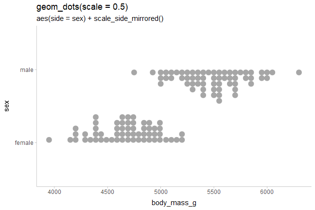

```r
gentoo = penguins %>%
  filter(species == "Gentoo", !is.na(sex))

gentoo %>%
  ggplot(aes(x = body_mass_g, y = sex, side = sex)) +
  geom_dots(scale = 0.5) +
  scale_side_mirrored(guide = "none") +
  ggtitle(
    "geom_dots(scale = 0.5)",
    'aes(side = sex) + scale_side_mirrored()'
  )
```

This can also be accomplished by setting side directly and omitting `scale_side_mirrored()`; e.g. via `aes(side = ifelse(sex == "male", "bottom", "top"))`.

Now we fit a logistic regression predicting sex based on body mass:

```r
m = glm(sex == "male" ~ body_mass_g, data = gentoo, family = binomial)
m
```

```
##
## Call:  glm(formula = sex == "male" ~ body_mass_g, family = binomial,
##     data = gentoo)
##
## Coefficients:
## (Intercept)  body_mass_g
##   -55.03337      0.01089
##
## Degrees of Freedom: 118 Total (i.e. Null);  117 Residual
## Null Deviance:       164.9
## Residual Deviance: 45.1  AIC: 49.1
```

Then we can overlay a fit line as a `stat_lineribbon()` (see `vignette("lineribbon")`) on top of the mirrored dotplots to create a *logit dotplot*:

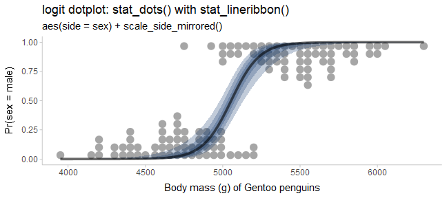

```r
# construct a prediction grid for the fit line
prediction_grid = with(gentoo,
  data.frame(body_mass_g = seq(min(body_mass_g), max(body_mass_g), length.out = 100))
)

prediction_grid %>%
  bind_cols(predict(m, ., se.fit = TRUE)) %>%
  mutate(
    # distribution describing uncertainty in log odds
    log_odds = dist_normal(fit, se.fit),
    # inverse-logit transform the log odds to get
    # distribution describing uncertainty in Pr(sex == "male")
    p_male = dist_transformed(log_odds, plogis, qlogis)
  ) %>%
  ggplot(aes(x = body_mass_g)) +
  geom_dots(
    aes(y = as.numeric(sex == "male"), side = sex),
    scale = 0.4,
    data = gentoo
  ) +
  stat_lineribbon(
    aes(ydist = p_male), alpha = 1/4, fill = "#08306b"
  ) +
  scale_side_mirrored(guide = "none") +
  coord_cartesian(ylim = c(0, 1)) +
  labs(
    title = "logit dotplot: stat_dots() with stat_lineribbon()",
    subtitle = 'aes(side = sex) + scale_side_mirrored()',
    x = "Body mass (g) of Gentoo penguins",
    y = "Pr(sex = male)"
  )
```